# Activism in the Information Age: How do social justice trends impact change?

Shane Freeborn

## Introduction to the Project

My main motivation behind this project was to evaluate the effect of social justice trends on social media and if they impact real change in our society. The main social justice trend I looked at was the Black Lives Matter movement, which is one of the biggest social movements in the past decade and has large social media presence.

## Data Description

Most of my data was acquired through the Washington Post’s police shootings dashboard, the Open Policing Project (Stanford University) and a twitter analysis of the #blacklivesmatter trend as well as counter movements. This data ranges from 2015-2018. My initial intentions were to show the impacts of the 2020 police protests following the murder of George Floyd in police custody, but there was not sufficient police data from 2019 and beyond.

The Washington Post data details every police shooting incident, in the line of duty. This data contains information the race of the victim, the circumstances of the shooting, and whether the person was armed. This data was collected through the FBI and CDC.

The Open Policing Project data details traffic stop data. The data in this includes age, race, and the outcome of each traffic stop. I will use this to see if there is a trend in policing minorities and people of color throughout the years.

Finally, the Twitter Data was collected through research done by Giorgi S, et al. This is a table that looks at data from 2013 through 2020. This data is used to track social media activity for BlackLivesMatter, BlueLivesMatter, and AllLivesMatter before and after police shooting incidents. This data was collected using Twitters API.

## Data Modeling

The relationships my model shows is the relationship between race and perceived threat level in instances where there has been a police shooting of a suspect. This allowed me to draw conclusions on the nature of these instances in order to predict social media trends following these shootings. In my research, those who support the Black Lives Matter movement generally protest police killings of unarmed black men and women (and children). When looking at this model, we can see that while there are by far more instances involving white suspects (make up majority of population in United States, ~70%), the second largest race shown is Black (who only make up 14% of the total population in the United States). The perceived threat level for unarmed black suspects is nearly as high as the white category as well.

```r
library(tidyverse)
```

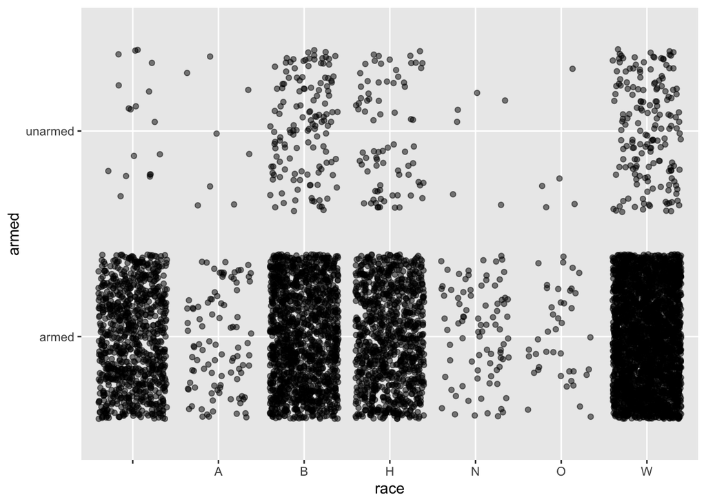

```r
police_incidents <- read.csv("data/fatal-police-shootings-data.csv")

police_incidents <- police_incidents %>%
  mutate(armed = case_when(armed != "unarmed" ~ "armed",
                           armed == "unarmed" ~ "unarmed",
                           armed == "undetermined" ~ "unknown"))
police_incidents <- police_incidents %>%
  mutate(threat_level = case_when(threat_level == "attack" ~ 1,
                                  threat_level == "other" ~ 0,
                                  threat_level == "undetermined" ~ 0))

police_incidents %>%
  group_by(manner_of_death) %>%
  ggplot(aes(x = race,
             y = armed
             )) +
    geom_jitter(alpha = .5) +
  geom_smooth(method = "lm")
```

```r
police_shootings_by_race_armed <- lm(threat_level ~ race + armed, data = police_incidents)
summary(police_shootings_by_race_armed)
```

```
##
## Call:
## lm(formula = threat_level ~ race + armed, data = police_incidents)
##
## Residuals:
##     Min      1Q  Median      3Q     Max
## -0.6940 -0.6082  0.3060  0.3228  0.7323
##
## Coefficients:
##              Estimate Std. Error t value Pr(>|t|)
## (Intercept)   0.64149    0.01546  41.499  < 2e-16 ***
## raceA        -0.09191    0.04849  -1.896  0.05805 .
## raceB         0.05255    0.01962   2.678  0.00743 **
## raceH        -0.03331    0.02114  -1.576  0.11511
## raceN        -0.04049    0.05194  -0.779  0.43578
## raceO         0.04807    0.07073   0.680  0.49673
## raceW         0.03573    0.01775   2.013  0.04414 *
## armedunarmed -0.28187    0.02371 -11.889  < 2e-16 ***
## ---
## Signif. codes:  0 '***' 0.001 '**' 0.01 '*' 0.05 '.' 0.1 ' ' 1
##
## Residual standard error: 0.473 on 6784 degrees of freedom
## Multiple R-squared:  0.02487,    Adjusted R-squared:  0.02387
## F-statistic: 24.72 on 7 and 6784 DF,  p-value: < 2.2e-16
```

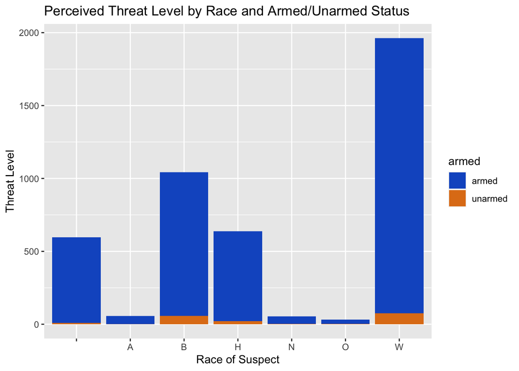

```r
police_shootings_by_race_armed %>%
  ggplot(aes(x = race,
             y = threat_level,
             fill = armed)) +
  geom_col() +
  ggtitle("Perceived Threat Level by Race and Armed/Unarmed Status") +
  xlab("Race of Suspect") +
  ylab("Threat Level") +
  scale_fill_manual(values = c("#145ac9", "#e07d19")) #colorblind accessibility
```

```r
police_shootings_by_race_armed
```

```
##
## Call:
## lm(formula = threat_level ~ race + armed, data = police_incidents)
##
## Coefficients:
##  (Intercept)         raceA         raceB         raceH         raceN
##      0.64149      -0.09191       0.05255      -0.03331      -0.04049
##        raceO         raceW  armedunarmed
##      0.04807       0.03573      -0.28187
```

```r
police_shootings_by_race <- lm(threat_level ~ race, data = police_incidents)
summary(police_shootings_by_race)
```

```
##
## Call:
## lm(formula = threat_level ~ race, data = police_incidents)
##
## Residuals:
##     Min      1Q  Median      3Q     Max
## -0.6692 -0.6361  0.3308  0.3394  0.4717
##
## Coefficients:
##             Estimate Std. Error t value Pr(>|t|)
## (Intercept)  0.63607    0.01561  40.747   <2e-16 ***
## raceA       -0.10777    0.04897  -2.201   0.0278 *
## raceB        0.03316    0.01976   1.679   0.0933 .
## raceH       -0.04843    0.02131  -2.272   0.0231 *
## raceN       -0.05365    0.05247  -1.023   0.3065
## raceO        0.02350    0.07143   0.329   0.7421
## raceW        0.02453    0.01790   1.370   0.1707
## ---
## Signif. codes:  0 '***' 0.001 '**' 0.01 '*' 0.05 '.' 0.1 ' ' 1
##
## Residual standard error: 0.4778 on 6785 degrees of freedom
## Multiple R-squared:  0.004554,   Adjusted R-squared:  0.003673
## F-statistic: 5.173 on 6 and 6785 DF,  p-value: 2.561e-05
```

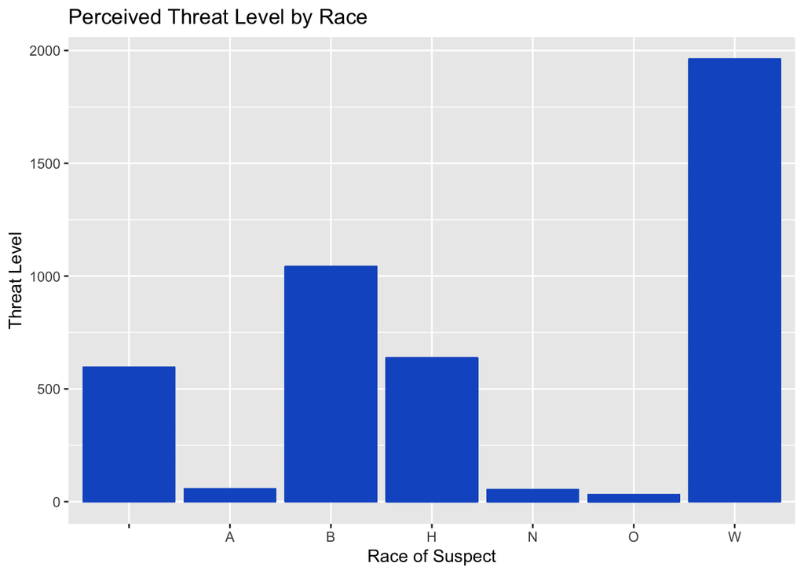

```r
#color changed for colorblind accessibility
police_shootings_by_race %>%
  ggplot(aes(x = race,
             y = threat_level)) +
  geom_col(col = "#145ac9") +
  ggtitle("Perceived Threat Level by Race") +
  xlab("Race of Suspect") +
  ylab("Threat Level")
```

```r
police_shootings_by_race
```

```
##
## Call:
## lm(formula = threat_level ~ race, data = police_incidents)
##
## Coefficients:
## (Intercept)        raceA        raceB        raceH        raceN        raceO
##     0.63607     -0.10777      0.03316     -0.04843     -0.05365      0.02350
##       raceW
##     0.02453
```